# Progress Memo 2

Final Project  
Data Science 1 with R (STAT 301-1)

Author

Claire Derksen

Published

November 22, 2023

## Github Repo Link

https://github.com/stat301-1-2023-fall/final-project-1-cadaora

## Data Changes

I decided to integrate data from 2021 to get a better idea of the effect of the COVID-19 pandemic. The original 2021 file had 58034 observations of 2988 variables and after filtering it had 13979 observations of 30 variables. Rather than getting rid of the variables I didn’t want as I did before, I decided to focus on variables from the categories drug use, mental health, depression, demographics, and income. I applied this to 2020 and 2019 and got data frames with 30 and 29 variables respectively.

The variable `IRVAPNICREC` exists only in 2020 and 2021 and it assesses recency of vaping nicotine. I decided to keep the variable since e-cigarettes and vapes are pretty popular among young adults.

I also decided to include young adults (18-25) that were not currently in college in order to have something to compare college students to. I created new rds files for young adults and deleted the previous college rds files.

## Altering Variables

There were different names for a variable that gave categorical mental illness indicator based on the 2012 model (`MICATPY` in 2021,`MI_CAT_U` in 2020 and 2021). I combined these into `MI_CAT_U` after using bind_rows to combine the years. I altered the character variable `FILEDATE` to the numeric variable `year` by getting rid of the month and day. I also added the variable `incollege` for easier comparisons. Before converting variables to factors I decided to assess missingness again.

| variable | n_miss | pct_miss |
| --- | --- | --- |
| ASDSWRK2 | 30284 | 83.770850 |
| ASDSREL2 | 30280 | 83.759785 |
| ASDSSOC2 | 30278 | 83.754253 |
| ASDSHOM2 | 30277 | 83.751487 |
| IRVAPNICREC | 14226 | 39.351608 |
| AMDEYR | 1239 | 3.427291 |
| year | 0 | 0.000000 |
| CIGOFRSM | 0 | 0.000000 |
| CIGWILYR | 0 | 0.000000 |
| STMRSSTDY | 0 | 0.000000 |

| year | variable | n_miss | pct_miss |
| --- | --- | --- | --- |
| 2021 | IRVAPNICREC | 0 | 0 |
| 2020 | IRVAPNICREC | 0 | 0 |
| 2019 | IRVAPNICREC | 14226 | 100 |

The ASDS questions measure how depressive feelings impair role domains (home management, work, close relationships with others, and social life) on the Sheehan Disability Scale (SDS). These questions were only asked for people who reported depressive symptoms. The nicotine vaping variable is missing only in observations from 2019.

## Coverting Variables to Different Classes

I created functions to convert similar variable types to factors. For any variable that had identical coding I created a function and used across() to convert those to factors. From this process I found that everyone in my subset skipped `CIGOFRSM`and `CIGWILYR` so I got rid of these variables. I initially tried using case_when() for to convert these however they didn’t keep the factor order. I instead used fct_recode() after factoring the initial numeric value. If I had any problems I specified the levels when using factor(). I wanted to keep the frequency variables , however, never having used a substance was coded as 91 while having used a substance before but not in the past month was coded as 93. I thought about coding both as NA and referring to the recency questions to determine the difference. I instead decided to code never as NA and not in the past month as 0 so I don’t have to refer to another variable. The variable `EDUSCHGRD2` had both legitimate skips which I coded as “Not in school” and blank/no answer which I coded as NA.

## Analysis

I wanted to first visualize the differences between the enrolled group and the unenrolled group.

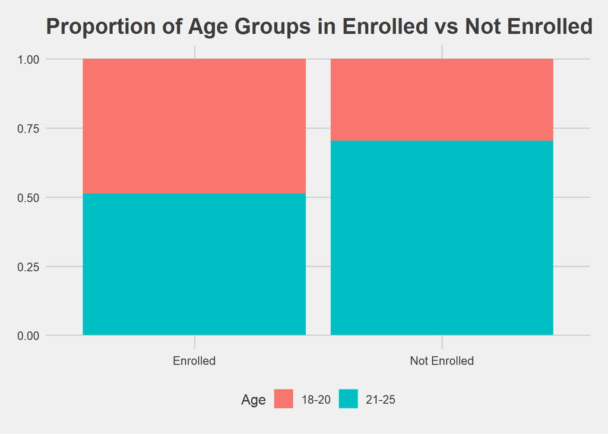

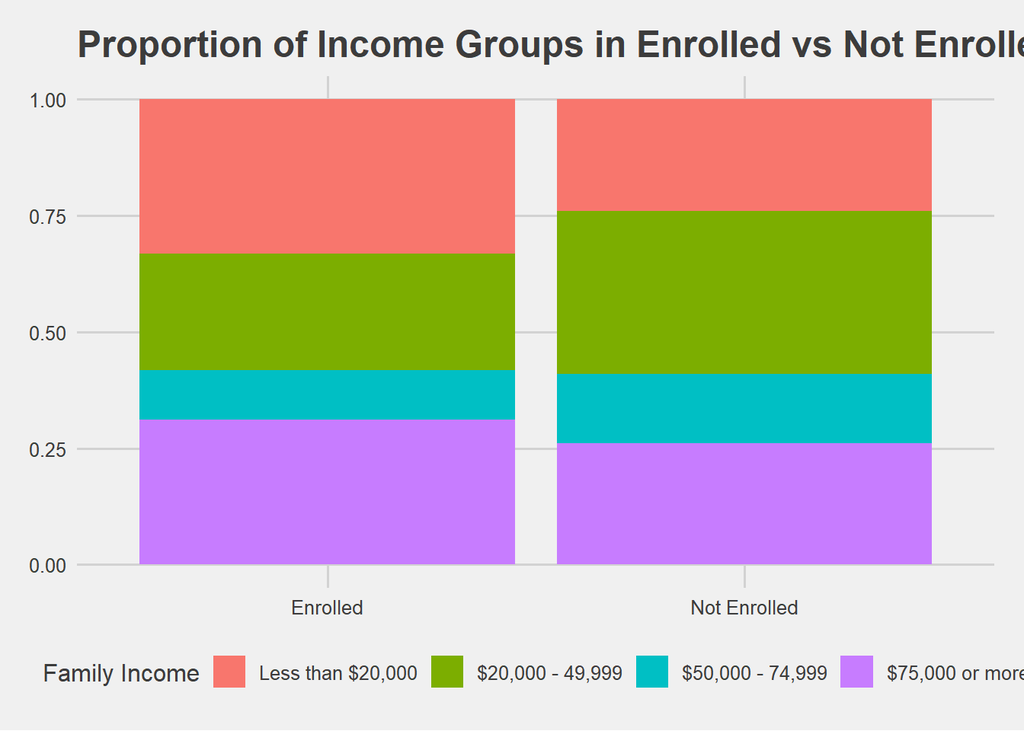

As expected the group not enrolled are slightly older. This group likely includes a good amount of college graduates. I expected the income of the not enrolled group to be generally lower however it seems that in the enrolled group the outer groups of less than $20,000 and $75,000 or more are while the middle groups are larger in the not enrolled group. Perhaps people that aren’t enrolled are able to contribute more to family income.

## Progress and Plan

I got pretty caught up in deciding which variables to keep so there is still space for more EDA. If there is time I would like to create a small codebook for the 29 variables and tidy the names using the janitor package. For analysis I’d like to start seeing what proportion of the not enrolled group are college graduates and look at the difference of income and age with college students. My concern is that I may end up exploring the impact of income on drug use rather than college enrollment.